# Example: Building a GLM

# 1. Data

We use the same dataset as Agresti Chapter 4.7. The question here is to understand the questioni: what affects the selling price of a house? This dataset contains $100$ house selling records in Gainesville, Florida.

```r
Houses <- read.table("Houses.dat", header = T)
Houses
```

| case | taxes | beds | baths | new | price | size |
| --- | --- | --- | --- | --- | --- | --- |
| 1 | 3104 | 4 | 2 | 0 | 279.9 | 2048 |
| 2 | 1173 | 2 | 1 | 0 | 146.5 | 912 |
| 3 | 3076 | 4 | 2 | 0 | 237.7 | 1654 |
| 4 | 1608 | 3 | 2 | 0 | 200.0 | 2068 |
| 5 | 1454 | 3 | 3 | 0 | 159.9 | 1477 |
| 6 | 2997 | 3 | 2 | 1 | 499.9 | 3153 |
| 7 | 4054 | 3 | 2 | 0 | 265.5 | 1355 |
| 8 | 3002 | 3 | 2 | 1 | 289.9 | 2075 |
| 9 | 6627 | 5 | 4 | 0 | 587.0 | 3990 |
| 10 | 320 | 3 | 2 | 0 | 70.0 | 1160 |

[output cut: 90 more lines]

- price: selling price of the house in thousands of dollars.
- size: size of the house in square feet
- taxes: annual property tax
- beds: number of bedrooms
- baths: number of bathrooms
- new: whether the house is a new construction or not

## 1.1 Some data exploration

Pair-wise scattor plots

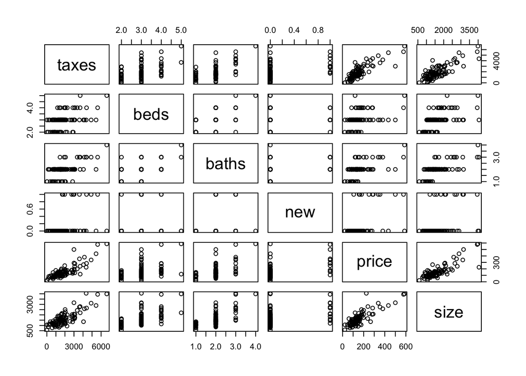

```r
pairs(Houses[, -1])
```

Pair-wise correlations

```r
cor(Houses[, -1])
```

```
##           taxes       beds     baths        new     price      size
## taxes 1.0000000 0.47392873 0.5948543 0.38087410 0.8419802 0.8187958
## beds  0.4739287 1.00000000 0.4922224 0.04931556 0.3939570 0.5447831
## baths 0.5948543 0.49222235 1.0000000 0.25148095 0.5582533 0.6582247
## new   0.3808741 0.04931556 0.2514810 1.00000000 0.4732608 0.3843277
## price 0.8419802 0.39395702 0.5582533 0.47326080 1.0000000 0.8337848
## size  0.8187958 0.54478311 0.6582247 0.38432773 0.8337848 1.0000000
```

# 2. Using a linear model

We include all covariates, and can decide whether we also want to include interactions

We can compare the model with and without interactions.

```r
fit.1 <- lm(price ~ size + new + baths + beds + taxes, data = Houses)
fit.2 <- lm(price ~ (size + new + beds + baths + taxes)^2, data = Houses)
anova(fit.1, fit.2, test = "Chisq")
```

|  | Res.Df | RSS | Df | Sum of Sq | Pr(>Chi) |
| --- | --- | --- | --- | --- | --- |
| 1 | 94 | 209754.3 | NA | NA | NA |
| 2 | 84 | 113596.0 | 10 | 96158.27 | 2.711037e-11 |

If we use the glm function, the default is also to use the Gaussian linear model, though the ANOVA table column names are different.

```r
fit.1 <- glm(price ~ size + new + baths + beds + taxes, data = Houses)
fit.2 <- glm(price ~ (size + new + baths + beds + taxes)^2, data = Houses)
anova(fit.1, fit.2, test = "Chisq")
```

|  | Resid. Df | Resid. Dev | Df | Deviance | Pr(>Chi) |
| --- | --- | --- | --- | --- | --- |
| 1 | 94 | 209754.3 | NA | NA | NA |
| 2 | 84 | 113596.0 | 10 | 96158.27 | 2.711037e-11 |

One thing to notice is that the deviance and residual deviance reported here are values with $\sigma^2 = 1$. The computation of p-values takes into account the estimation of $\sigma^2$.

We can even compare with a model adding third order interactions.

```r
fit.3 <- glm(price ~ (size + new + beds + baths + taxes)^3, data = Houses)
anova(fit.2, fit.3, test = "Chisq")
```

|  | Resid. Df | Resid. Dev | Df | Deviance | Pr(>Chi) |
| --- | --- | --- | --- | --- | --- |
| 1 | 84 | 113596.01 | NA | NA | NA |
| 2 | 76 | 91903.28 | 8 | 21692.74 | 0.0216889 |

We see that the third-order interactions also seems help.

## 2.1 Model checking for the linear models

All the above p-values are valid only when the equal variance assumption holds. So before we further select a good linear model, we should check whether the residuals look good.

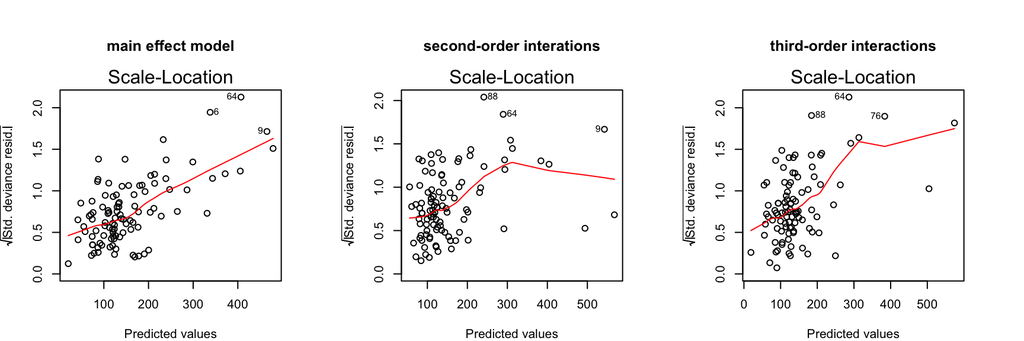

```r
par(mfrow=c(1,3), mar = c(4, 4, 6, 4))
plot(fit.1, which = 3, main = "main effect model")
plot(fit.2, which = 3, main = "second-order interations")
plot(fit.3, which = 3, main = "third-order interactions")
```

We can see that for all three models, the residual variances tend to increase with the fitted values. This suggests that the Gaussian linear model assuming equal variance of the noise is not proper.

This suggests that we would like to change to a GLM model.

# 3. Using a Gamma GLM

## 3.1 Gamma distribution (Chapter 4.7.2)

The density function is
$$f(y;k, \mu) = \frac{(k/\mu)^k}{\Gamma(k)}e^{-ky/\mu}y^{k -1}$$

with $\mathbb{E}(y) = \mu$ and $\text{Var}(y) = \mu^2/k$. The canonical parameter is $\theta = 1/\mu$ and the dispersion function is $a(\phi) = 1/k$.

## 3.2 Applying the Gamma GLM to our dataset

As a housing price is always positive, we can choose to use a Gamma GLM model, which allows the standard deviations of the noise to increase with $\mu_i$.

If we use the same link as the linear model, we see that the residual variance trend using the Gamma GLM is much better, though there seems to be a bit over correction.

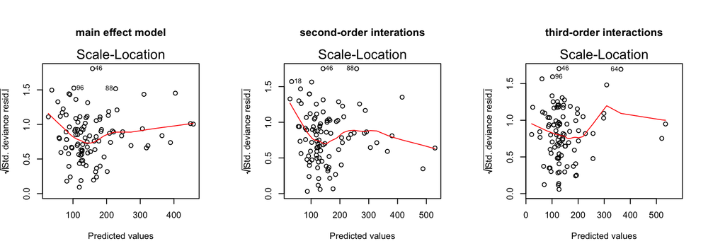

```r
fit.gamma1 <- glm(price ~ size + new + beds + baths + taxes, family = Gamma(link = identity), data = Houses)
fit.gamma2 <- glm(price ~ (size + new + beds + baths + taxes)^2, family = Gamma(link = identity), data = Houses)
fit.gamma3 <- glm(price ~ (size + new + beds + baths + taxes)^3, family = Gamma(link = identity), data = Houses)
par(mfrow=c(1,3), mar = c(4, 4, 6, 4))
plot(fit.gamma1, which = 3, main = "main effect model")
plot(fit.gamma2, which = 3, main = "second-order interations")
plot(fit.gamma3, which = 3, main = "third-order interactions")
```

## 3.3 Building a good Gamma GLM model

How to build a good Gamma GLM model for predicting the housing price? (You can read Agresti Chapter 4.7.1 for how a linear model is chosen). Here, “good” means that we want to find a model that can fit the data well while being as simple as possible to avoid unnessary uncertainties.

The following steps to pick a good model are a bit at-hoc. I would just like to provide a simple guidance and it’s fine if you have a different opinion.

```r
anova(fit.gamma1, fit.gamma2, test = "LRT")
```

|  | Resid. Df | Resid. Dev | Df | Deviance | Pr(>Chi) |
| --- | --- | --- | --- | --- | --- |
| 1 | 94 | 6.509248 | NA | NA | NA |
| 2 | 84 | 5.550293 | 10 | 0.9589546 | 0.1443698 |

What we find out is that the interaction terms may not be really necessary when we use a Gamma GLM.

Now we compute the deviance analysis table for the main effect model and see if some covariates are not that important.

```r
anova(fit.gamma1,  test = "LRT")
```

|  | Df | Deviance | Resid. Df | Resid. Dev | Pr(>Chi) |
| --- | --- | --- | --- | --- | --- |
| NULL | NA | NA | 99 | 31.940111 | NA |
| size | 1 | 20.6567311 | 98 | 11.283380 | 1.063933e-67 |
| new | 1 | 0.3483046 | 97 | 10.935076 | 2.397478e-02 |
| beds | 1 | 0.3542208 | 96 | 10.580855 | 2.280860e-02 |
| baths | 1 | 0.1391355 | 95 | 10.441719 | 1.536277e-01 |
| taxes | 1 | 3.9324718 | 94 | 6.509248 | 3.310670e-14 |

The result suggests that the baths covariate may also be unnecessary to include.

```r
fit.gamma4 <- glm(price ~ size + new + beds + taxes, family = Gamma(link = identity), data = Houses)
anova(fit.gamma4,  test = "LRT")
```

|  | Df | Deviance | Resid. Df | Resid. Dev | Pr(>Chi) |
| --- | --- | --- | --- | --- | --- |
| NULL | NA | NA | 99 | 31.940111 | NA |
| size | 1 | 20.6567311 | 98 | 11.283380 | 1.140683e-67 |
| new | 1 | 0.3483046 | 97 | 10.935076 | 2.400716e-02 |
| beds | 1 | 0.3542208 | 96 | 10.580855 | 2.283987e-02 |
| taxes | 1 | 3.9279903 | 95 | 6.652865 | 3.469166e-14 |

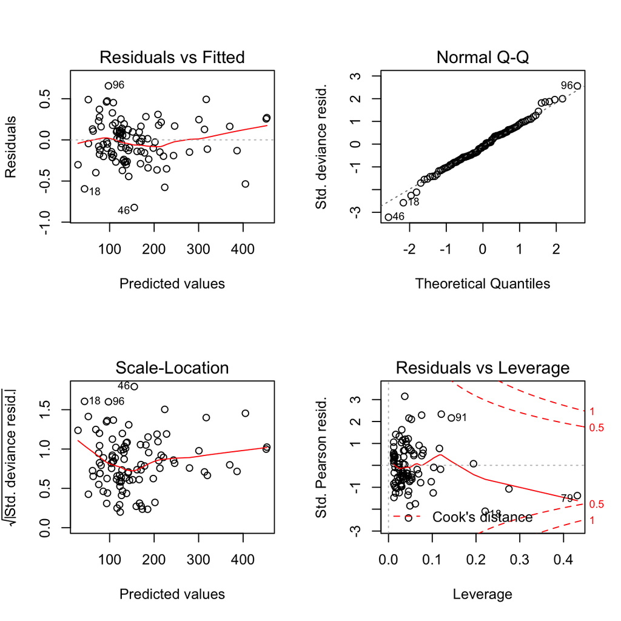

```r
par(mfrow=c(2,2))
plot(fit.gamma4)
```

```r
summary(fit.gamma4)
```

```
##
## Call:
## glm(formula = price ~ size + new + beds + taxes, family = Gamma(link = identity),
##     data = Houses)
##
## Deviance Residuals:
##      Min        1Q    Median        3Q       Max
## -0.82167  -0.18460  -0.02599   0.14511   0.65720
##
## Coefficients:
##               Estimate Std. Error t value Pr(>|t|)
## (Intercept)  23.829561  13.540229   1.760  0.08164 .
## size          0.066093   0.012128   5.450 3.97e-07 ***
## new          22.494342  19.256820   1.168  0.24568
## beds        -17.031149   6.339464  -2.687  0.00852 **
## taxes         0.037877   0.005124   7.393 5.61e-11 ***
## ---
## Signif. codes:  0 '***' 0.001 '**' 0.01 '*' 0.05 '.' 0.1 ' ' 1
##
## (Dispersion parameter for Gamma family taken to be 0.06837392)
##
##     Null deviance: 31.9401  on 99  degrees of freedom
## Residual deviance:  6.6529  on 95  degrees of freedom
## AIC: 1003.1
##
## Number of Fisher Scoring iterations: 6
```

The deviance computed from GLM still is not devided by $a(\phi)$, which is estimated as $a(\hat \phi) = 0.0684$. For example, the deviance for covariate “new” in our deviance table is $0.3483/0.0684 = 5.1$, resulting in a p-value of $0.024$ after comparing with $\chi_1^2$.